# Term diposits campaign

Jose M Sallan

22 October 2019

# 1 Objective of the analysis

We want to answer the following question:

- Which kind of customers are most likely to subscribe (yes/no) a term deposit (variable y)?

This means that we need to build a model to predict if a customer will suscribe a term deposit.

# 2 Methodology

## 2.1 The dataset

The variables in our dataset are:

1. age (numeric)
2. job: type of job (categorical)
3. marital: marital status (categorical)
4. education: educational level (categorical)
5. default: has credit in default? (binary)
6. balance: average yearly balance, in euros (numeric)
7. housing: has housing loan? (binary)
8. loan: has personal loan? (binary) From here, information related with the last contact of the current campaign:
9. contact: contact communication type (categorical)
10. day: last contact day of the month (numeric)
11. month: last contact month of year (categorical)
12. duration: last contact duration, in seconds (numeric) Other attributes to consider:
13. campaign: number of contacts performed during this campaign and for this client (numeric)
14. pdays: number of days that passed by after the client was last contacted from a previous campaign (numeric, -1 means client was not previously contacted)
15. previous: number of contacts performed before this campaign and for this client (numeric)
16. poutcome: outcome of the previous marketing campaign (categorical) Output variable (desired target):
17. y: has the client subscribed a term deposit? (binary)

The individuals in this dataset are people contacted in a campaign to sell term diposits. Some individuals have been contacted in previous campaigns.

## 2.2 Data analysis

We can classify the variables as follows:

- Demographics (variables 1 to 4)
- Description of each individual as a customer (variables 5 to 8)
- Impact of campaign on customer (variables 9 to 13)
- Impact of previous campaigns on customer (variables 14 a 16)
- Target variable (variable 17)

Then, we will look for signfiicant differences of the proportion of people suscribing term diposits (value of “yes” in the y variable). In some cases, we can be interested in examining how many people there is in each group.

# 3 Results

## 3.1 Examining data

We will start loading the data into R being categorical variables as factors, and summarise the resulting data frame:

```r
library(dplyr)
library(tidyr)
library(ggplot2)
```

```r
banks <- read.csv2("bank.csv")
summary(banks)
```

```
##       age                 job          marital         education
##  Min.   :19.00   management :969   divorced: 528   primary  : 678
##  1st Qu.:33.00   blue-collar:946   married :2797   secondary:2306
##  Median :39.00   technician :768   single  :1196   tertiary :1350
##  Mean   :41.17   admin.     :478                   unknown  : 187
##  3rd Qu.:49.00   services   :417
##  Max.   :87.00   retired    :230
##                  (Other)    :713
##  default       balance      housing     loan           contact
##  no :4445   Min.   :-3313   no :1962   no :3830   cellular :2896
##  yes:  76   1st Qu.:   69   yes:2559   yes: 691   telephone: 301
##             Median :  444                         unknown  :1324
##             Mean   : 1423
##             3rd Qu.: 1480
##             Max.   :71188
##
##       day            month         duration       campaign
##  Min.   : 1.00   may    :1398   Min.   :   4   Min.   : 1.000
##  1st Qu.: 9.00   jul    : 706   1st Qu.: 104   1st Qu.: 1.000
##  Median :16.00   aug    : 633   Median : 185   Median : 2.000
##  Mean   :15.92   jun    : 531   Mean   : 264   Mean   : 2.794
##  3rd Qu.:21.00   nov    : 389   3rd Qu.: 329   3rd Qu.: 3.000
##  Max.   :31.00   apr    : 293   Max.   :3025   Max.   :50.000
##                  (Other): 571
##      pdays           previous          poutcome      y
##  Min.   : -1.00   Min.   : 0.0000   failure: 490   no :4000
##  1st Qu.: -1.00   1st Qu.: 0.0000   other  : 197   yes: 521
##  Median : -1.00   Median : 0.0000   success: 129
##  Mean   : 39.77   Mean   : 0.5426   unknown:3705
##  3rd Qu.: -1.00   3rd Qu.: 0.0000
##  Max.   :871.00   Max.   :25.0000
##
```

### 3.1.1 Demographic variables

Let’s look for differences between the two groups defined by the outcome variables that can be explained with demographic variables:

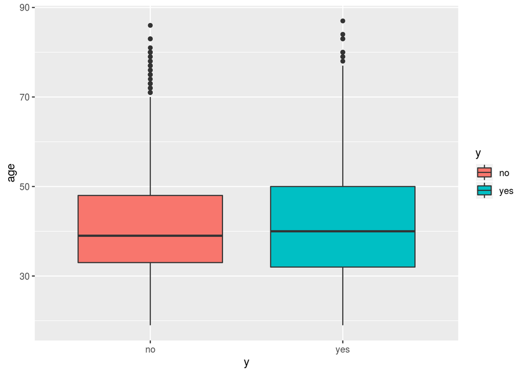

```r
banks %>% ggplot(aes(x=y, y=age, fill=y)) + geom_boxplot()
```

There does not seem to be differences across the range of ages of the two groups.

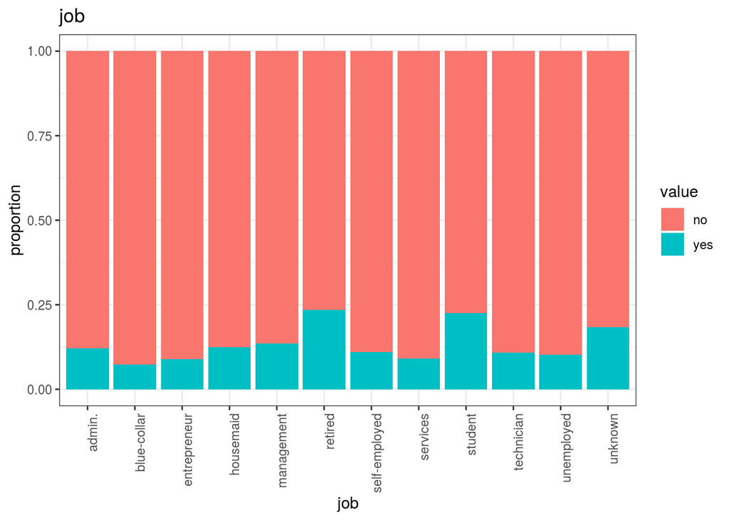

```r
banks %>% group_by(job) %>% summarise(yes=sum(y=="yes")/n(), no=sum(y=="no")/n()) %>% gather(value, proportion, -job) %>% ggplot(aes(x=job, y=proportion, fill=value)) + geom_bar(stat = "identity") + theme_bw() + theme(axis.text.x = element_text(angle = 90, hjust = 1)) + labs(title="job")
```

When we look for differences across jobs, we can see that students and retired customers tend to suscribe more deposits.

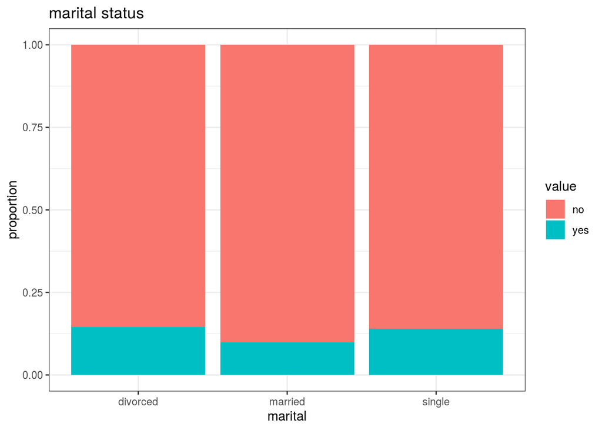

```r
banks %>% group_by(marital) %>% summarise(yes=sum(y=="yes")/n(), no=sum(y=="no")/n()) %>% gather(value, proportion, -marital) %>% ggplot(aes(x=marital, y=proportion, fill=value)) + geom_bar(stat = "identity") + theme_bw() + labs(title="marital status")
```

Divorced and single individuals tend to suscribe more deposits than married customers.

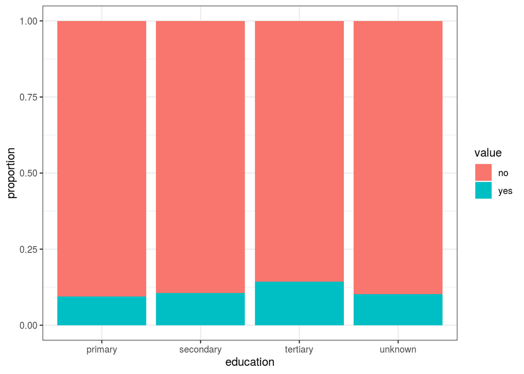

```r
banks %>% group_by(education) %>% summarise(yes=sum(y=="yes")/n(), no=sum(y=="no")/n()) %>% gather(value, proportion, -education) %>% ggplot(aes(x=education, y=proportion, fill=value)) + geom_bar(stat = "identity") + theme_bw() + labs("education")
```

We can observe a slight tendency of acquiring more deposits as education grows.

In all cases the differences observed are relatively small.

### 3.1.2 Customer variables

Let’s examine the potential discriminant effect of customer variables.

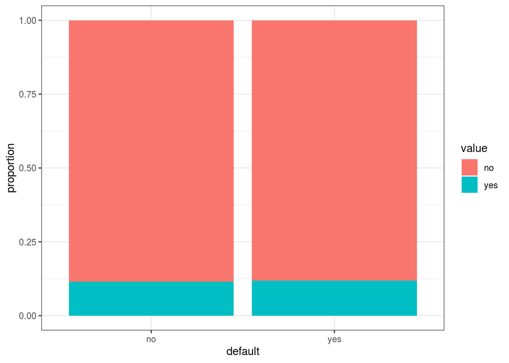

```r
banks %>% group_by(default) %>% summarise(yes=sum(y=="yes")/n(), no=sum(y=="no")/n()) %>% gather(value, proportion, -default) %>% ggplot(aes(x=default, y=proportion, fill=value)) + geom_bar(stat = "identity") + theme_bw()
```

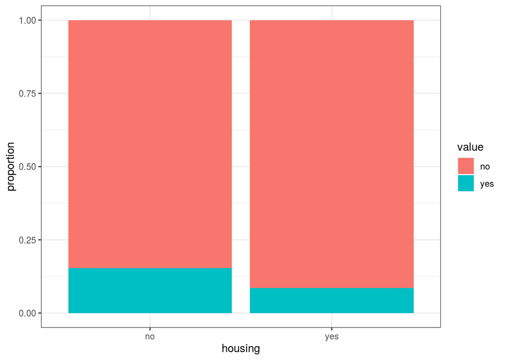

```r
banks %>% group_by(housing) %>% summarise(yes=sum(y=="yes")/n(), no=sum(y=="no")/n()) %>% gather(value, proportion, -housing) %>% ggplot(aes(x=housing, y=proportion, fill=value)) + geom_bar(stat = "identity") + theme_bw()
```

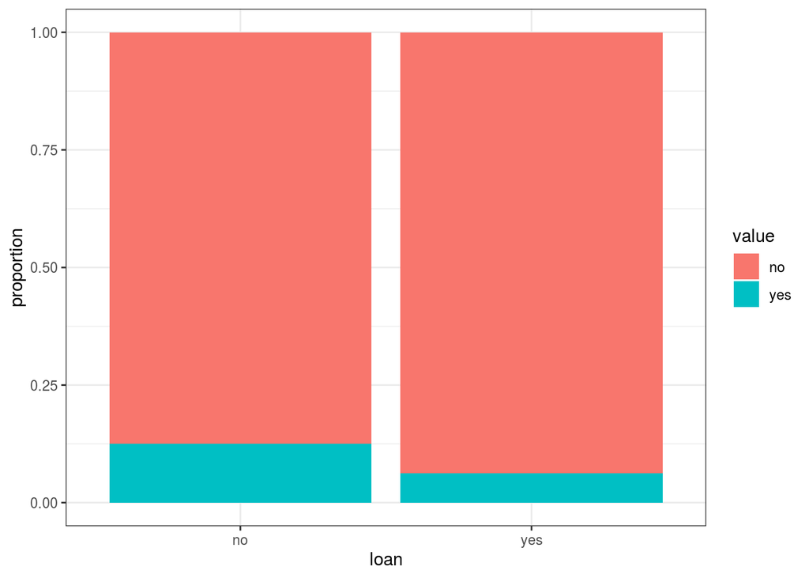

```r
banks %>% group_by(loan) %>% summarise(yes=sum(y=="yes")/n(), no=sum(y=="no")/n()) %>% gather(value, proportion, -loan) %>% ggplot(aes(x=loan, y=proportion, fill=value)) + geom_bar(stat = "identity") + theme_bw()
```

The behoviour of defaulted customers does not seem to be different from not defaulted. Customers with housing and personal loans tend to suscribe term diposits less frequently than customers that have not suscribed loans.

The effect of loans can be related with marital status. We will check if there are differences of people getting a housing and personal loan across marital status:

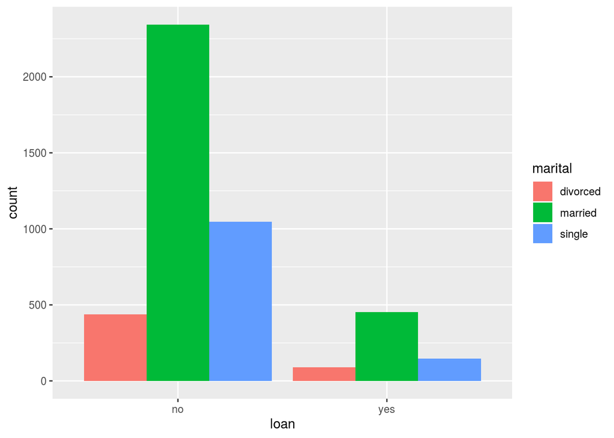

```r
banks %>% group_by(loan, marital) %>% summarise(count=n()) %>% ggplot(aes(x=loan, y=count, fill=marital)) + geom_bar(stat = "identity", position="dodge")
```

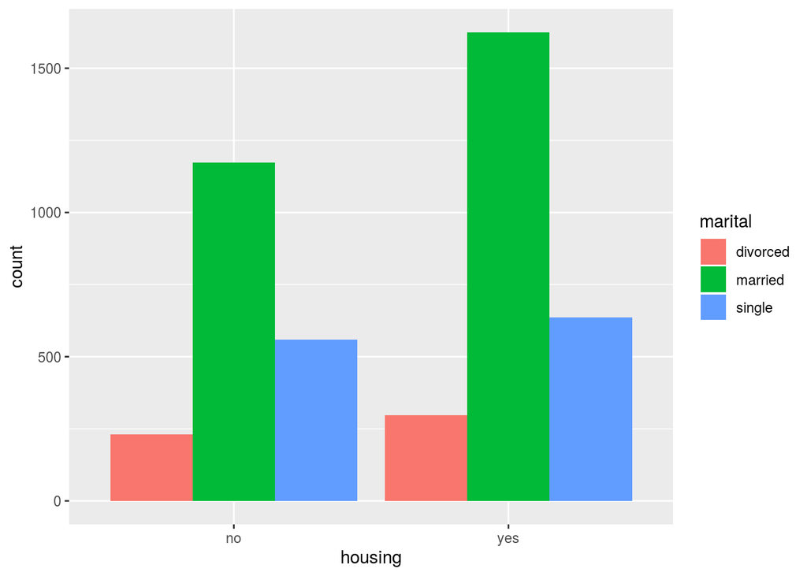

```r
banks %>% group_by(housing, marital) %>% summarise(count=n()) %>% ggplot(aes(x=housing, y=count, fill=marital)) + geom_bar(stat = "identity", position="dodge")
```

We can see that married customers tend to have more personal loans that divorced and single, so they tend to suscribe less term diposits.

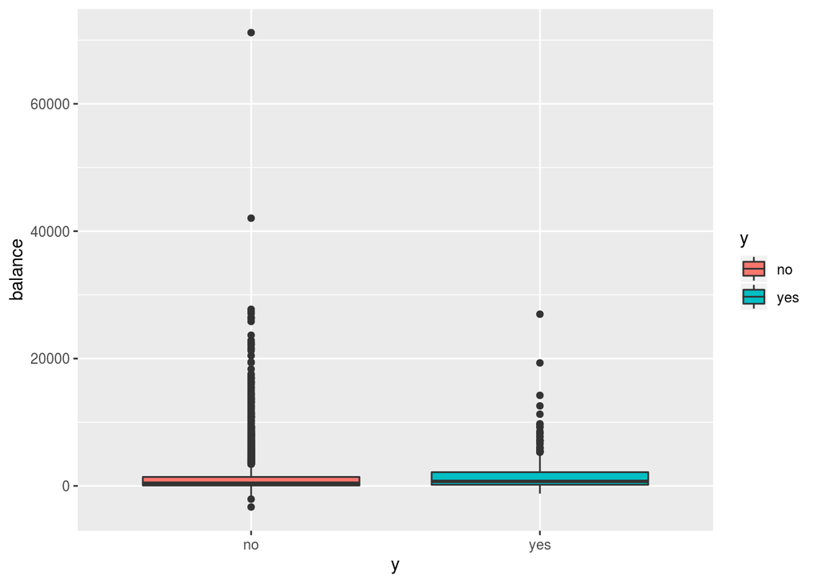

```r
banks %>% ggplot(aes(x=y, y=balance, fill=y)) + geom_boxplot()
```

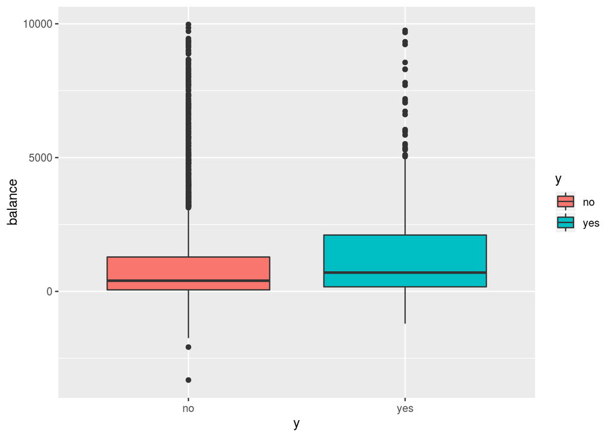

```r
banks %>% filter(balance<=10000) %>% ggplot(aes(x=y, y=balance, fill=y)) + geom_boxplot()
```

The plots above look for differences between the value of balance of both groups. We can see large differences in balance (there are many outliers with high value of balance), so we have examined differences between groups examining values of balance equal or smaller than 10,000 in the second plot. We observe that loans tend to be suscribed with people with higher values of balance, although the differences in balance are not significant:

```r
t.test(balance ~ y, data=banks)
```

```
##
##  Welch Two Sample t-test
##
## data:  balance by y
## t = -1.4347, df = 752.36, p-value = 0.1518
## alternative hypothesis: true difference in means is not equal to 0
## 95 percent confidence interval:
##  -399.63379   62.14559
## sample estimates:
##  mean in group no mean in group yes
##          1403.212          1571.956
```

### 3.1.3 Campaign

Let’s look at variables describing the marketing campaign.

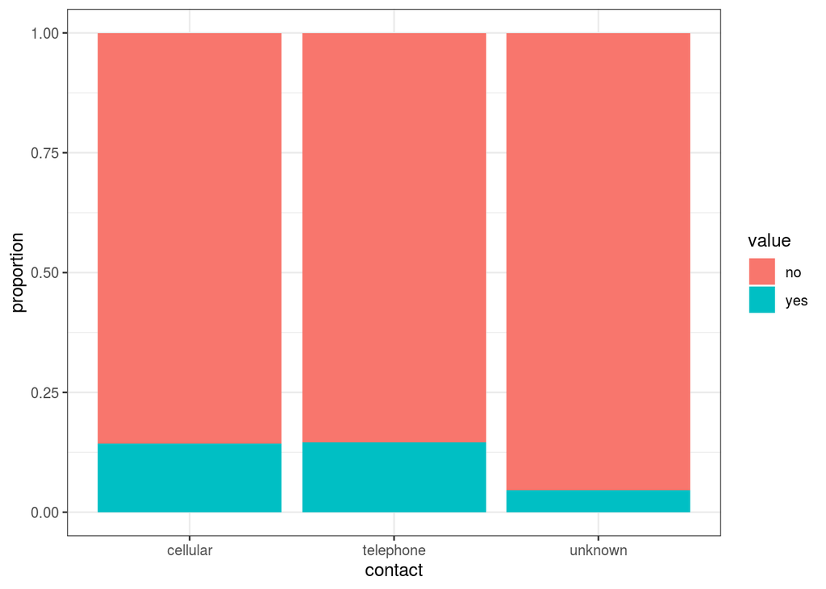

```r
banks %>% group_by(contact) %>% summarise(yes=sum(y=="yes")/n(), no=sum(y=="no")/n()) %>% gather(value, proportion, -contact) %>% ggplot(aes(x=contact, y=proportion, fill=value)) + geom_bar(stat = "identity") + theme_bw()
```

```r
banks %>% group_by(y) %>% summarise(mean(campaign))
```

```
## # A tibble: 2 x 2
##   y     `mean(campaign)`
##   <fct>            <dbl>
## 1 no                2.86
## 2 yes               2.27
```

Examining the duration of the call, here we see significant differences:

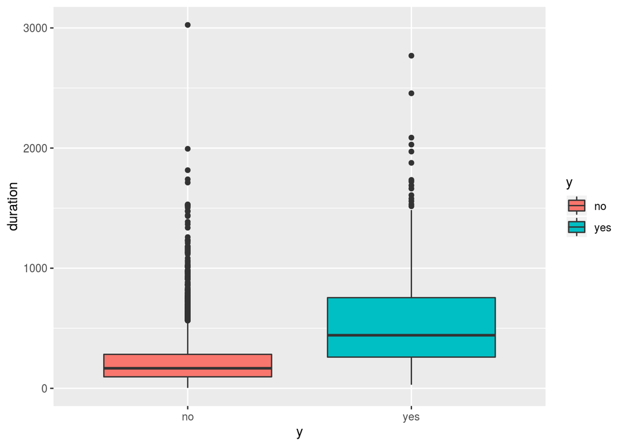

```r
banks %>% ggplot(aes(x=y, y=duration, fill=y)) + geom_boxplot()
```

```r
t.test(duration ~ y, data=banks)
```

```
##
##  Welch Two Sample t-test
##
## data:  duration by y
## t = -18.736, df = 559.97, p-value < 2.2e-16
## alternative hypothesis: true difference in means is not equal to 0
## 95 percent confidence interval:
##  -360.6134 -292.1772
## sample estimates:
##  mean in group no mean in group yes
##          226.3475          552.7428
```

Customers that later suscribed the deposited tend to maintain longer calls when contacted. So call duration, rather than number of calls, seems to predict a positive outcome of the campaign.

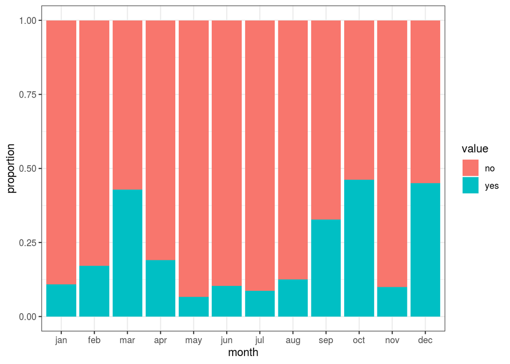

```r
banks$month <- factor(banks$month, levels=c("jan", "feb", "mar", "apr", "may", "jun", "jul", "aug", "sep", "oct", "nov", "dec"))
banks %>% group_by(month) %>% summarise(yes=sum(y=="yes")/n(), no=sum(y=="no")/n()) %>% gather(value, proportion, -month) %>% ggplot(aes(x=month, y=proportion, fill=value)) + geom_bar(stat = "identity") + theme_bw()
```

When we examine differences of success rate across months, we find relevant differences between months. Seems like march, september, october and december are the most effective months to get new deposit loans.

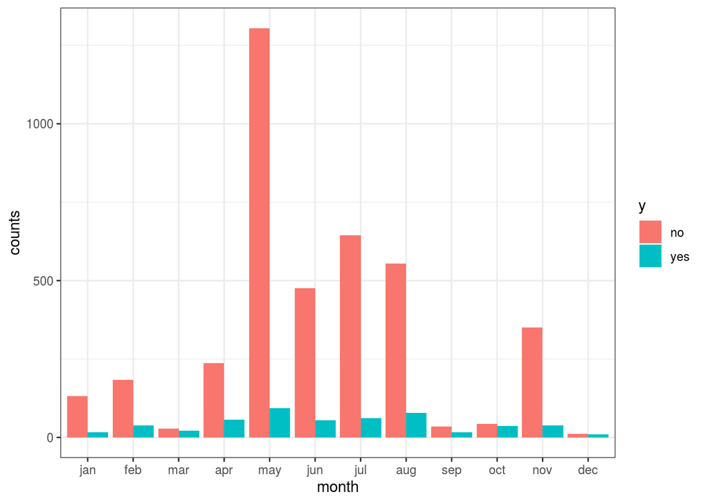

```r
banks %>% group_by(month, y) %>% summarise(counts=n()) %>% ggplot(aes(x=month, y=counts, fill=y)) + geom_bar(stat = "identity", position = "dodge") + theme_bw()
```

We observe, though, that this high rate of success is obtained in months when the number of calls has been small.

We will now examine the effect of the results of previous campaigns in the present campaign. We can distinguish two groups in the sample:

- People not contacted in previous campaigns: they have `pdays=-1`, `previous=0` and `poutcome="unkown"`. There are 3705 not contacted previously individuals.
- People contacted in previous campaigns. There are 816 previously contacted individuals.

We define a new variable to label individuals contacted in previous campaigns. Note that we are modifying `banks`, so we need to overwrite the data frame:

```r
banks <- banks %>% mutate(contacted = ifelse(pdays!=-1, "yes", "no"))
```

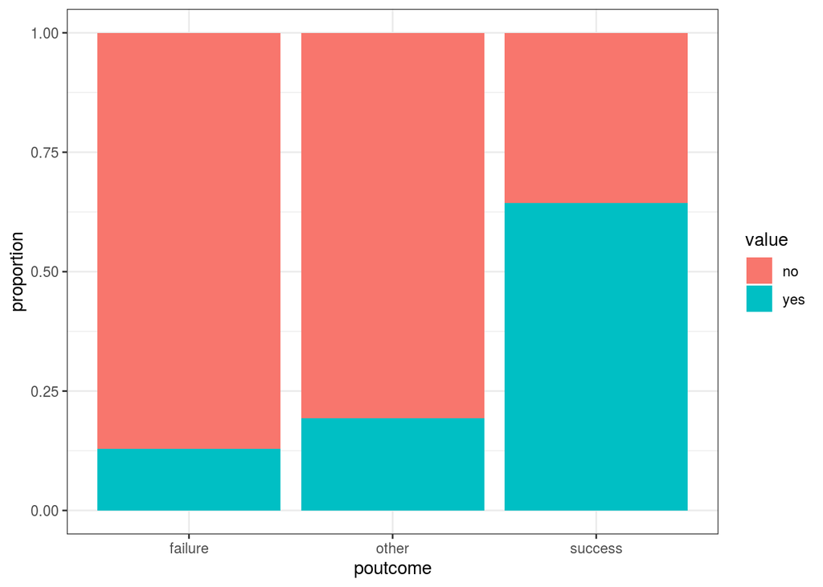

```r
banks %>% filter(contacted=="yes") %>% group_by(poutcome) %>% summarise(yes=sum(y=="yes")/n(), no=sum(y=="no")/n()) %>% gather(value, proportion, -poutcome) %>% ggplot(aes(x=poutcome, y=proportion, fill=value)) + geom_bar(stat = "identity") + theme_bw()
```

If we restrict the analysis of previously contacted individuals, we can see that the strongest predictor of success in the present campaign is that the customers belong to the successful group in previous campaigns.

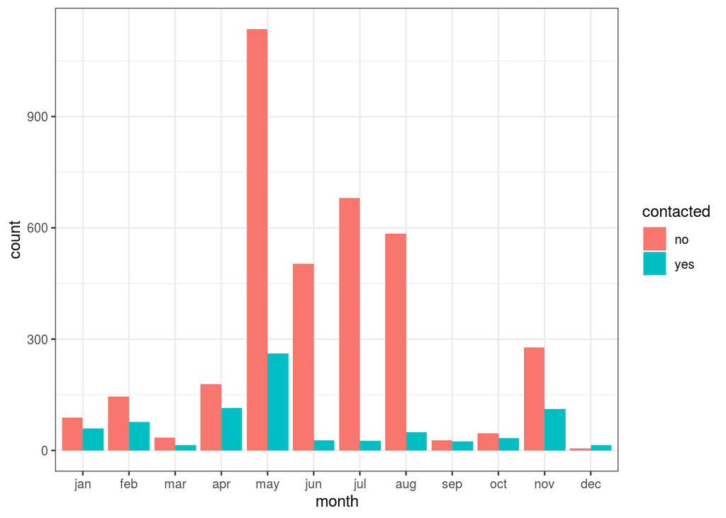

```r
banks %>% group_by(month, contacted) %>% summarise(count=n()) %>% ggplot(aes(x=month, y = count, fill=contacted)) + geom_bar(stat = "identity", position = "dodge") + theme_bw()
```

The above graph shows that the months were campaigns were most sucessful were months with a high proportion of individuals coming from previous campaigns.

# 4 Conclusion

The strongest predictor of success in the suscription of new term deposits campaign is that the customer has been sucessfully contacted in previous campaigns. To a lesser extent, the variables job, marital status and educational level present differences between sucessful and unsucessful contacts. People with no personal or housing loans tend to suscribe term deposits. As for the marketing campaign, duration of call is a predictor of interest in suscribing a term deposit.

As a conclusion, we can recommend the bank to build a dataset of people sucessfully contacted in marketing campaigns, as a potential target for new campaigns. We also recommend re-contacting customers that have made a long contact in the present campaign.